# R Notebook

Using KDEs and MCPs I tried to examine how much space a goshawks use, whether the amount of space used varies between individuals and by sex, or by breeding period (nestling, fledgling, etc.). Unfortunately, I don’t really have enough data to look at anything other than the nestling period or for all periods, but I do have the groundwork for figuring it out later, once I get the rest of my data.

Those are very basic questions, and I do need to answer them. But the question I’m really more interested in is not how *much* space goshawks use, but *how* they use it, and whether they use different parts of it for different purposes. I think the T-LoCoh method will be very fun for this.

[LoCoh Tutorial](http://www.danaseidel.com/MovEco-R-Workshop/Materials/Day3/LoCoH/)

[Home range plus](https://movementecologyjournal.biomedcentral.com/articles/10.1186/2051-3933-1-2)

[T-LoCoh package](http://tlocoh.r-forge.r-project.org/)

[A cross-validation-based approach for delimiting reliable home range estimates](https://www.ncbi.nlm.nih.gov/pmc/articles/PMC5586009/)

```r
# Load some libraries.
library('tidyverse')
library('dplyr')
library('lubridate')
library('sf')
library('tlocoh') # Requires the FNN package to be installed.
library('sp')
library('rgdal')
# Read in the data.
df <- read.csv('../data/processed/telem_all.csv',
               header=TRUE, stringsAsFactors=FALSE) %>%
  drop_na('lat')
# Select just one site to work with.
ska <- df %>% filter(site == 'SKA')
# To make a lxy object, we need datetime and coordinates.
# Do the datetime thing.
datetime <- ymd_hms(ska$datetime, tz='America/Vancouver')
# Do the spatial thing. This is a bit different than usual.
ska.sf <- SpatialPoints(ska[ , c('lon', 'lat')],
  proj4string=CRS('+proj=longlat +ellps=WGS84 +datum=WGS84 +no_defs')) %>%
  spTransform(CRS('+proj=utm +zone=10 +datum=WGS84 +units=m +no_defs'))
ska.coords <- coordinates(ska.sf)
colnames(ska.coords) <- c('x', 'y')
# Make a lxy object.
ska.lxy <- xyt.lxy(xy=ska.coords, dt=datetime, id='HAR05',
                   proj4string=CRS('+proj=utm +zone=10 +datum=WGS84 +units=m +no_defs'))
# Look at some stuff.
summary(ska.lxy)
```

```
Summary of LoCoH-xy object: ska.lxy
***Locations
```

| id | num.pts | dups |
| --- | --- | --- |
| HAR05 | 4671 | 16 |

```
***Time span
```

| id | begin | end | period |
| --- | --- | --- | --- |
| HAR05 | 2019-06-23 | 2019-09-04 | 73 days |

```
***Spatial extent
     x: 433738.3 - 442366
     y: 5484831.8 - 5500004.3
  proj: +proj=utm +zone=10 +datum=WGS84 +units=m +no_defs +ellps=WGS84 +towgs84=0,0,0
***Movement properties
```

|  | id | time.step.median | d.bar | vmax |
| --- | --- | --- | --- | --- |
| 1 | HAR05 | 960 (16min) | 75.7186 | 4.622568 |

```
***Ancilliary Variables:
   -none-
***Nearest-neighbor set(s):
   none saved
```

I can’t show the `plot` output bc reasons, but it’s really cool.

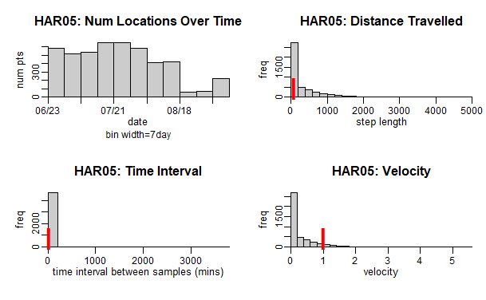

```r
hist(ska.lxy)
```

The median time step of 16 minutes shows that generally, the tag isn’t missing too many points, since it’s supposd to take a point every 15 minutes. The step length and velocity also show that the bird mostly travels short distances at low speed. That may be biased downward because of roosting behavior.

The next step apparently is to check for “bursts”, which are a bit different than what is usually referred to with that term and are artefacts of sampling (ie GPS glitches) that result in too-dense clusters of points.

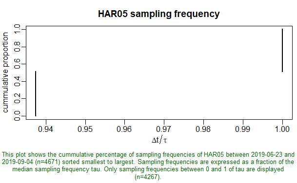

```r
lxy.plot.freq(ska.lxy, cp=T)
```

Aaaand I have no idea to interpret this. But it looks like all of my frequencies fall between 0.93 and 1.0, so I think that’s ok. I also tried thinning by frequency (with sampling frequency of 960 s/16 min, since that’s the median frequency) and it made no difference.

To start with I’m going to ignore time (s=0) and use the k method (number of nearest neighbords) just to get a feel for how this works. I’ll use a range of k values to see what looks nicest.

```r
# Create a lhs object with k and s defined.
ska.lxy <- lxy.nn.add(ska.lxy, s=0, k=25)
```

```
Finding nearest neighbors for id=HAR05 (n=4671),
  num.parent.pts=4671, mode=Fixed-k, k=25, s=0, method=Euclidean
  - computing values of kmax, rmax, and amax...Done
  - set of neighbors (re)named: HAR05|vmax|s0|n4671|kmax25|rmax18.4|amax286.7

Done. Nearest neighbor set(s) created / updated:
  HAR05|vmax|s0|n4671|kmax25|rmax18.4|amax286.7
Total time: 1.1 secs
```

```r
ska.lhs <- lxy.lhs(ska.lxy, k=3*3:8, s=0)
```

[output not shown]

[output cut: 1198 more lines]

```
  |++++++++++++++++++++++++++++++++++++++++++++++++  |  96%
  |++++++++++++++++++++++++++++++++++++++++++++++++  |  97%
  |+++++++++++++++++++++++++++++++++++++++++++++++++ |  98%
  |++++++++++++++++++++++++++++++++++++++++++++++++++|  99%
  |++++++++++++++++++++++++++++++++++++++++++++++++++| 100%
  Calculating area and perimeter...Done.
  Calculating the time span of each hull...Done.
The following hullsets were generated:
    HAR05.pts4671.k9.s0.kmin0
    HAR05.pts4671.k12.s0.kmin0
    HAR05.pts4671.k15.s0.kmin0
    HAR05.pts4671.k18.s0.kmin0
    HAR05.pts4671.k21.s0.kmin0
    HAR05.pts4671.k24.s0.kmin0
Total time: 2.1 mins
```

```r
# Add isopleths.
ska.lhs <- lhs.iso.add(ska.lhs)
```

[output not shown]

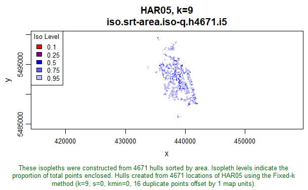

```r
plot(ska.lhs, iso=T, k=9,ufipt=F)
```

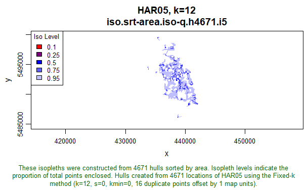

```r
plot(ska.lhs, iso=T, k=12, ufipt=F)
```

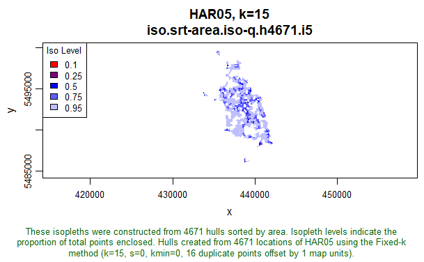

```r
plot(ska.lhs, iso=T, k=15, ufipt=F)
```

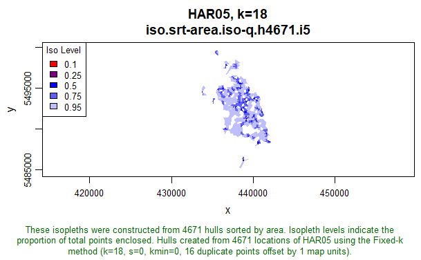

```r
plot(ska.lhs, iso=T, k=18, ufipt=F)
```

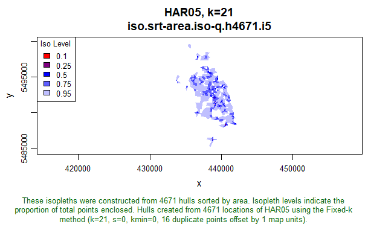

```r
plot(ska.lhs, iso=T, k=21, ufipt=F)
```

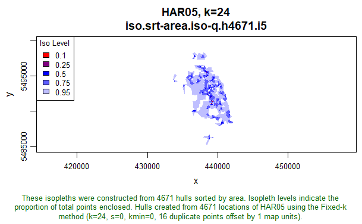

```r
plot(ska.lhs, iso=T, k=24, ufipt=F)
```

I think a k of 18 or 21 looks nice. I can also try a few other things, looking for plots with a large jump between k values or a high edge-area ratio.

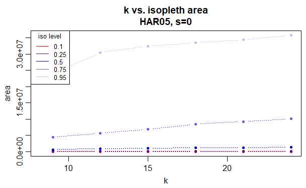

```r
lhs.plot.isoarea(ska.lhs)
```

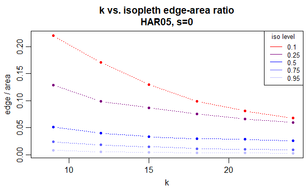

```r
lhs.plot.isoear(ska.lhs)
```

```r
ska.lhs.k18 <- lhs.select(ska.lhs, k=18)
```

18 and 21 still look nice, so I’ll go with k=18.

So far I’ve been ignoring time, but I can’t do that forever. So now I need to pick a s value. Based on space-time equity and using the `sfinder` function, I can see that i I’m interested in daily foraging behavior, then a s of 0.007316 seems appropriate.

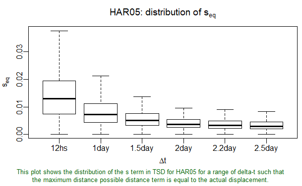

```r
s.find <- lxy.plot.sfinder(ska.lxy, delta.t=3600*c(12,24,36,48,54,60))
```

```r
s.parity.24hrs <- s.find[[1]]$svals[["86400"]]
median(s.parity.24hrs)
```

```
[1] 0.007316036
```

So then if I run it all again with a s value as well as a k value.

```r
# Add s value to hull object.
ska.lxy <- lxy.nn.add(ska.lxy, s=0.007, k=18)
```

[output not shown]

[output cut: 54 more lines]

```
  |++++++++++++++++++++++++++++++++++++++++++++++    |  92%
  |++++++++++++++++++++++++++++++++++++++++++++++    |  93%
  |+++++++++++++++++++++++++++++++++++++++++++++++   |  94%
  |++++++++++++++++++++++++++++++++++++++++++++++++  |  95%
  |++++++++++++++++++++++++++++++++++++++++++++++++  |  96%
  |++++++++++++++++++++++++++++++++++++++++++++++++  |  97%
  |+++++++++++++++++++++++++++++++++++++++++++++++++ |  98%
  |++++++++++++++++++++++++++++++++++++++++++++++++++|  99%
  |++++++++++++++++++++++++++++++++++++++++++++++++++| 100%
  - computing values of kmax, rmax, and amax...Done
  - set of neighbors (re)named: HAR05|vmax|s0.007|n4671|kmax18|rmax270.8|amax2746.7

Done. Nearest neighbor set(s) created / updated:
  HAR05|vmax|s0.007|n4671|kmax18|rmax270.8|amax2746.7
Total time: 2.1 mins
```

```r
# Then make lhs object.
ska.lhs.time <- lxy.lhs(ska.lxy, k=18, s=0.007)
```

[output not shown]

[output cut: 159 more lines]

```
  |++++++++++++++++++++++++++++++++++++++++++++++    |  92%
  |++++++++++++++++++++++++++++++++++++++++++++++    |  93%
  |+++++++++++++++++++++++++++++++++++++++++++++++   |  94%
  |++++++++++++++++++++++++++++++++++++++++++++++++  |  95%
  |++++++++++++++++++++++++++++++++++++++++++++++++  |  96%
  |++++++++++++++++++++++++++++++++++++++++++++++++  |  97%
  |+++++++++++++++++++++++++++++++++++++++++++++++++ |  98%
  |++++++++++++++++++++++++++++++++++++++++++++++++++|  99%
  |++++++++++++++++++++++++++++++++++++++++++++++++++| 100%
  Calculating area and perimeter...Done.
  Calculating the time span of each hull...Done.
  Identifying enclosed points...Done.
The following hullsets were generated:
    HAR05.pts4671.k18.s0.007.kmin0
Total time: 30.7 secs
```

```r
# Add isopleths.
ska.lhs.time <- lhs.iso.add(ska.lhs.time)
```

```
Merging hulls into isopleths
HAR05.pts4671.k18.s0.007.kmin0
  Sorting hulls by area...Done.
  Unioning hulls

  |++++++++++                                       |  20%
  |++++++++++++++++++++                             |  40%
  |+++++++++++++++++++++++++++++                    |  60%
  |+++++++++++++++++++++++++++++++++++++++          |  80%
  |+++++++++++++++++++++++++++++++++++++++++++++++++| 100%
Total time: 3.3 secs
```

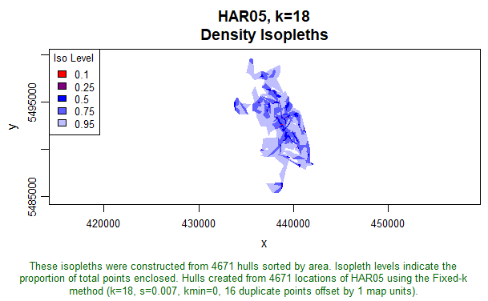

```r
# And plot.
ska.lhs.time.k18 <- lhs.select(ska.lhs.time, k=18)
plot(ska.lhs.time.k18, iso=TRUE)
```

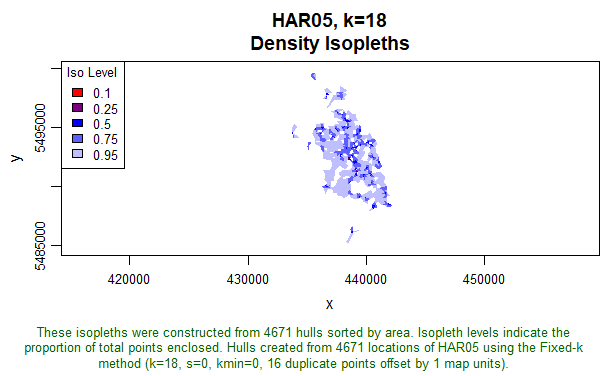

```r
plot(ska.lhs.k18, iso=TRUE)
```

```r
# And save it.
lhs.save(ska.lhs.time.k18, dir='../data/processed')
```

```
LoCoH-hullset ska.lhs.time.k18 saved as 'ska.lhs.time.k18' to:
  C:\Users\Gwyn\sfuvault\move-space\data\processed\har05.n4671.s0.007.k18.iso.lhs.03.RData
```

I think keeping k=18 still looks nice with the new time-sensitive hulls. *Except* that after all this, it turns out the k is not a good parameter to use with time-sensitive hulls, a should be used instead.

## Action items

- Compare male and female home ranges.
- Compare coastal and transition zone home ranges.
- Locate nighttime roost sites.
- Write up notes on wtf a hull actually and how time works.